# 3. Klauzule abuzywne

## 3. Komputery zastąpiły rachmistrzów, czy niedługą zastąpią prawników i lekarzy?

Poza nowymi możliwościami w dziedzinie analizy obrazu, uczenie maszynowe można też wykorzystać do rozumienia języka. Dzięki temu możemy ocenić czy opinia jest pozytywna, czy negatywna, poprawić skuteczność wyszukiwarek, a także nauczyć komputer pisania całkiem sensownie brzmiącej prozy (GPT-3). Na tej lekcji przyjżymy się, czy komputer jest w stanie wyszukać w umowach niezgodne z prawem zapisy.

### Dane

Dane pozyskamy z niedawnego konkursu ogłoszonego przez UOKIK. Są one w pliku CSV, gdzie w jednej kolumnie jest kawałek tekstu umowy, a w drugiej etykieta nadana przez ekspertów UOKIKu.

```python
import pandas as pd
from tqdm import tqdm
tqdm.pandas()
```

```python
data = pd.read_csv('dane treningowe_I etap.csv')
```

```python
data.head(5)
```

|  | text | class |
| --- | --- | --- |
| 0 | Wszelka korespondencja wysyłana przez Pożyczko... | KLAUZULA_ABUZYWNA |
| 1 | W przypadku opóźnień Pożyczkobiorcy w spłacie ... | KLAUZULA_ABUZYWNA |
| 2 | W przypadku opóźnień Pożyczkobiorcy w spłacie ... | KLAUZULA_ABUZYWNA |
| 3 | Pożyczkobiorca zleca firmie Narodowy Fundusz P... | KLAUZULA_ABUZYWNA |
| 4 | Od niespłaconej w terminie raty Pożyczkobiorca... | KLAUZULA_ABUZYWNA |

Ponieważ cały tekst nie mieści nam się w tabelce zmienimy nieco ustawienia biblioteki Pandas.

```python
pd.set_option('display.max_colwidth', None)
```

```python
data
```

|  | text | class |
| --- | --- | --- |
| 0 | Wszelka korespondencja wysyłana przez Pożyczkodawcę na adres zamieszkania podany w umowie oraz na e-mail zostaje uznana za skutecznie doręczoną. Zmiana adresu e-mail oraz adresu zamieszkania musi być … | KLAUZULA_ABUZYWNA |
| 1 | W przypadku opóźnień Pożyczkobiorcy w spłacie pożyczki Pożyczkodawca ma prawo raz dziennie telefonicznie upomnieć Pożyczkobiorcę do spłaty pożyczki. Za każdy telefon do Pożyczkobiorcy Pożyczkodawca na… | KLAUZULA_ABUZYWNA |
| 2 | W przypadku opóźnień Pożyczkobiorcy w spłacie pożyczki Pożyczkodawca ma prawo wysłać jedno wezwanie dziennie do spłaty pożyczki za pomocą poczty tradycyjnej oraz mailowej na adresy podane w umowie. Za… | KLAUZULA_ABUZYWNA |
| 3 | Pożyczkobiorca zleca firmie Narodowy Fundusz Pożyczkowy Sp. z o.o. poręczenie swojej pożyczki i zobowiązuje się zapłacić na rzecz Pożyczkodawcy kwotę 1000 zł (słownie: jeden tysiąc złotych) miesięczni… | KLAUZULA_ABUZYWNA |
| 4 | Od niespłaconej w terminie raty Pożyczkobiorca zapłaci Pożyczkodawcy opłaty karne w wysokości 200 złotych w stosunku dziennym | KLAUZULA_ABUZYWNA |
| ... | ... | ... |
| 4279 | CESJA PRAW Z UBEZPIECZENIA NIERUCHOMOŚCI | BEZPIECZNE_POSTANOWIENIE_UMOWNE |
| 4280 | Przyznanie i prolongowanie Kredytów na zakup pojazdów Zgodnie z warunkami wynikającymi z umowy | BEZPIECZNE_POSTANOWIENIE_UMOWNE |
| 4281 | Dotyczy to również niniejszych Warunków Imprez Turystycznych, stanowiących integralną część umowy o udział w imprezie turystycznej. | BEZPIECZNE_POSTANOWIENIE_UMOWNE |
| 4282 | Suma ubezpieczenia w kolejnych ubezpieczeniach powinna być równa wartości nieruchomości na moment przedłużenia ubezpieczenia, z zastrzeżeniem ust. | BEZPIECZNE_POSTANOWIENIE_UMOWNE |
| 4283 | Saldo Konta Oszczędnościowego Oprocentowanie promocyjne Do 200 000 PLN dla Nowych środków 3,00%* Pozostałe środki zgodnie z pkt. | BEZPIECZNE_POSTANOWIENIE_UMOWNE |

4284 rows × 2 columns

Nastepnie możemy zrobić szybką analizę tych danych i przerobić je na wygodniejszą postać:

```python
data['class'].unique()
```

```
array(['KLAUZULA_ABUZYWNA', 'BEZPIECZNE_POSTANOWIENIE_UMOWNE'],
      dtype=object)
```

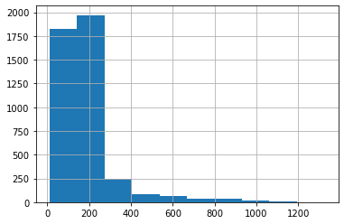

```python
data['text'].str.len().hist()
```

```python
data['abusive'] = data['class'] == 'KLAUZULA_ABUZYWNA'
```

```python
del data['class']
```

```python
data
```

|  | text | abusive |
| --- | --- | --- |
| 0 | Wszelka korespondencja wysyłana przez Pożyczkodawcę na adres zamieszkania podany w umowie oraz na e-mail zostaje uznana za skutecznie doręczoną. Zmiana adresu e-mail oraz adresu zamieszkania musi być … | True |
| 1 | W przypadku opóźnień Pożyczkobiorcy w spłacie pożyczki Pożyczkodawca ma prawo raz dziennie telefonicznie upomnieć Pożyczkobiorcę do spłaty pożyczki. Za każdy telefon do Pożyczkobiorcy Pożyczkodawca na… | True |
| 2 | W przypadku opóźnień Pożyczkobiorcy w spłacie pożyczki Pożyczkodawca ma prawo wysłać jedno wezwanie dziennie do spłaty pożyczki za pomocą poczty tradycyjnej oraz mailowej na adresy podane w umowie. Za… | True |
| 3 | Pożyczkobiorca zleca firmie Narodowy Fundusz Pożyczkowy Sp. z o.o. poręczenie swojej pożyczki i zobowiązuje się zapłacić na rzecz Pożyczkodawcy kwotę 1000 zł (słownie: jeden tysiąc złotych) miesięczni… | True |
| 4 | Od niespłaconej w terminie raty Pożyczkobiorca zapłaci Pożyczkodawcy opłaty karne w wysokości 200 złotych w stosunku dziennym | True |
| ... | ... | ... |
| 4279 | CESJA PRAW Z UBEZPIECZENIA NIERUCHOMOŚCI | False |
| 4280 | Przyznanie i prolongowanie Kredytów na zakup pojazdów Zgodnie z warunkami wynikającymi z umowy | False |
| 4281 | Dotyczy to również niniejszych Warunków Imprez Turystycznych, stanowiących integralną część umowy o udział w imprezie turystycznej. | False |
| 4282 | Suma ubezpieczenia w kolejnych ubezpieczeniach powinna być równa wartości nieruchomości na moment przedłużenia ubezpieczenia, z zastrzeżeniem ust. | False |
| 4283 | Saldo Konta Oszczędnościowego Oprocentowanie promocyjne Do 200 000 PLN dla Nowych środków 3,00%* Pozostałe środki zgodnie z pkt. | False |

4284 rows × 2 columns

### Tokenizacja i word embeddings

Żeby dowolny tekst mógł zostać przeanalizowany przez algorytm uczenia maszynowego, musimy tekst zamienić na liczby. Oczywiście komputer już to robi (każda litera jest kodowana przez jedną liczbę), ale jak możemy się domysleć, taki sposób kodowania nie ułatwi nam dalszej analizy. Dużo lepiej jest podzielić tekst na słowa i każde słowo zamianić na zestaw liczb, które koduje jego znaczenie.

Skorzystamy z biblioteki Spacy, która zawiera wiele algorytmów wspierających przetwarzanie tekstu.

```python
!conda update --yes spacy
```

[output not shown]

[output cut: 136 more lines]

[output not shown]

Po zainstalowaniu Spacy musimy jeszcze pobrać bazę danych mapowań ze słów na wektory liczb dla odpowiedniego języka (w tym wypadku dla polskiego):

```python
!python -m spacy download pl_core_news_lg
```

```
     |████████████████████████████████| 612.6 MB 18 kB/s /s eta 0:00:01   |███▊                            | 70.3 MB 78.4 MB/s eta 0:00:07     |█████████████████████████▌      | 487.6 MB 103.1 MB/s eta 0:00:02
✔ Download and installation successful
You can now load the package via spacy.load('pl_core_news_lg')
```

```python
import spacy
```

```python
wordmodel = spacy.load('pl_core_news_lg')
```

```python
tokens = wordmodel(data['text'][0])
```

Spacy potrafi podzielić nasz tekst na zdania, słowa oraz dla każdego słowa zwrócić nam wektor liczb (jego embedding).

```python
list(tokens.sents)
```

```
[Wszelka korespondencja wysyłana przez Pożyczkodawcę na adres zamieszkania podany w umowie oraz na e-mail zostaje uznana za skutecznie doręczoną.,
 Zmiana adresu e-mail oraz adresu zamieszkania musi być dostarczona do Pożyczkodawcy osobiście]
```

```python
[str(w) for w in tokens]
```

```
['Wszelka',
 'korespondencja',
 'wysyłana',
 'przez',
 'Pożyczkodawcę',
 'na',
 'adres',
 'zamieszkania',
 'podany',
 'w',
 'umowie',
 'oraz',
 'na',
 'e',
 '-',
 'mail',
 'zostaje',
 'uznana',
 'za',
 'skutecznie',
 'doręczoną',
 '.',
 'Zmiana',
 'adresu',
 'e',
 '-',
 'mail',
 'oraz',
 'adresu',
 'zamieszkania',
 'musi',
 'być',
 'dostarczona',
 'do',
 'Pożyczkodawcy',
 'osobiście']
```

```python
embeddings = [w.vector for w in tokens]
embeddings[:2]
```

[output not shown]

[output cut: 67 more lines]

[output not shown]

```python
np.stack(embeddings).shape
```

```
(36, 300)
```